# Analysing My Instagram Feed: A Personal Data Story

## Title Card

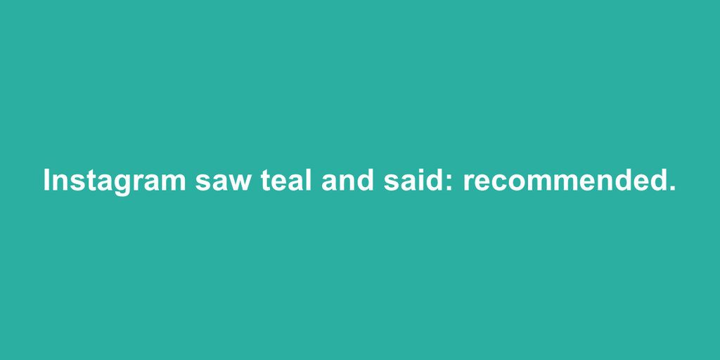

## The nature of my data and what I am analysing

Every time I open Instagram, the app instantly shows me a single post at the very top of my feed. Because Instagram’s feed is personalised, that single post I see is influenced by my own habits, interests, and past engagement. I want to understand why certain posts appear first and what this reveals about how the recommendation system interprets my behaviour.

To investigate this, I logged data about the first post I saw each time I opened the app. For each entry, I recorded:

- what the post was generally about (its content category)
- the type of post (image(s), videos, reel, mixed, or advertisement)
- how long I viewed the post (time spent)
- whether or not I tapped the “like” button

This dataset allows me to analyse both what Instagram chooses to show me first and how I interact with that content. My goal is to uncover patterns in the types of posts that appear at the top of my feed and to explore how my engagement behaviour aligns with Instagram’s predictions.

## When Instagram Shows Me Certain Types of First Contents

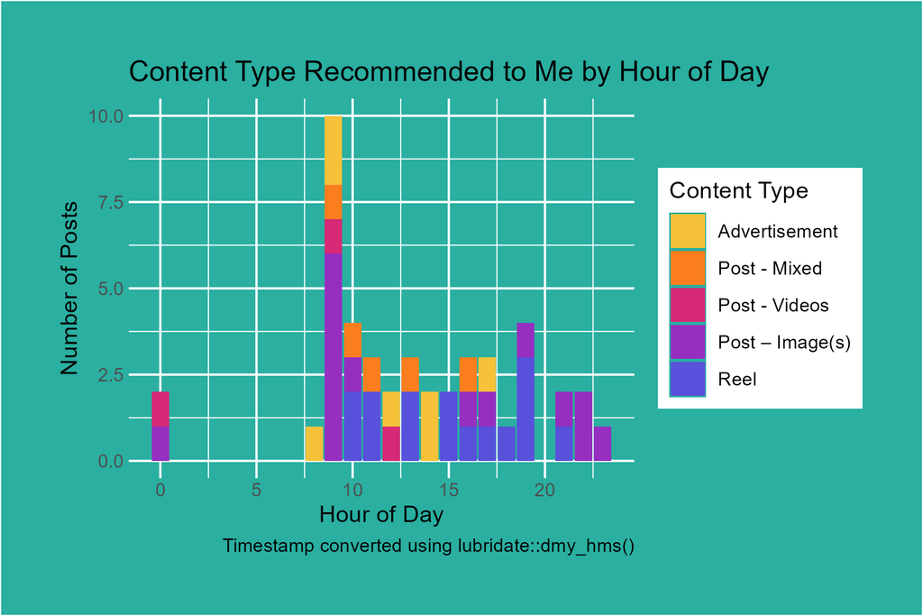

This bar chart shows how the first post varies depending on the time of day. The most common time I open Instagram is between 9 am and 10 am, and during this hour the first content type recommended to me is usually a post with only images. In the afternoon and evening (1 pm to 8 pm), the first post is more often a reel, which may reflect Instagram’s assumption that short, fast‑paced content suits my scrolling behaviour during these periods. Late at night (9 pm to 1 am), the first post shifts back toward image‑only posts, suggesting that Instagram may prioritise calmer or more static content when I tend to scroll more casually.

## Does Instagram Show Me Posts I’m Likely to Engage With?

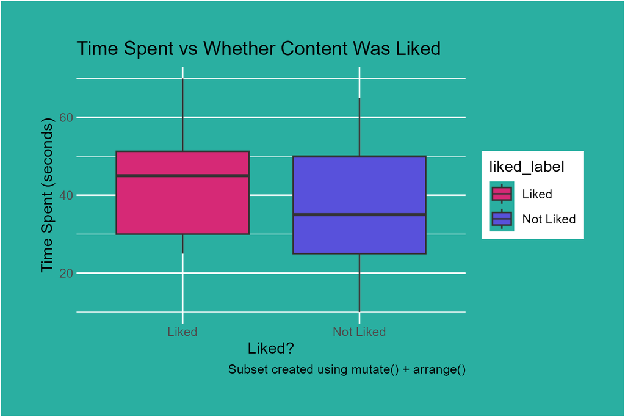

Boxplots comparing time spent on first posts I liked versus those I did not like. Liked posts show a higher median time spent.

## Which Categories Instagram Prefers to Show Me First

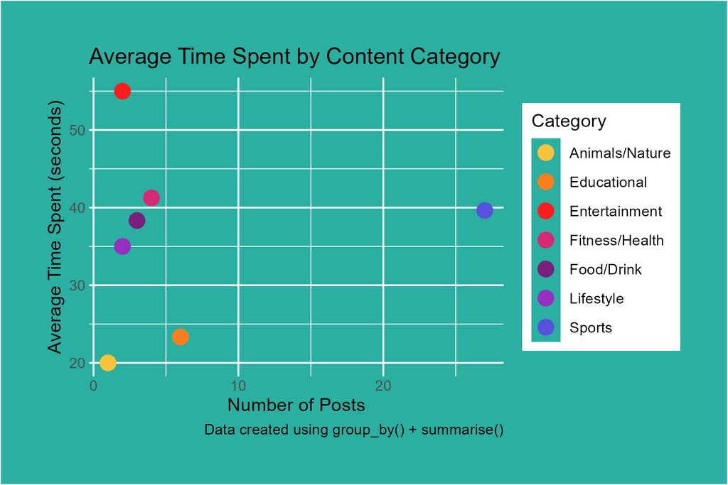

Scatter plot showing average time spent per content category versus how often that category appeared as the first post. Entertainment has the highest average time spent, while sports appears frequently with moderate engagement.

This scatter plot compares how often each category appeared as the first post with how long I spent viewing it. The Sports category appeared far more often than the other six categories, likely because I follow many sports accounts and have recently interacted with a lot of sports content. In contrast, the Entertainment category held my attention for much longer than any other category, even though it appeared far less frequently. This suggests that while I do not regularly view entertainment content, I am highly engaged when it does appear. Together, these patterns indicate that Instagram may prioritise habit‑based predictions (what I usually see first) rather than purely optimising for engagement time.

## What This Suggests About Instagram’s Recommendation System

Across all three visualisations, clear patterns emerge about how Instagram decides what to show me first. The timing plot suggests that Instagram uses my daily routine to shape its recommendations, showing image‑based posts in the morning and late at night, and reels during the afternoon and evening. The engagement plots show that while Instagram is often successful at predicting what I will like, it sometimes prioritises content that is attention‑grabbing rather than content I genuinely enjoy. The category plot further reveals that Instagram relies heavily on habit‑based predictions: Sports appears first most often because I frequently interact with sports content, even though Entertainment holds my attention for much longer.

Together, these findings suggest that Instagram’s first‑post recommendation is influenced by a combination of my past behaviour, my viewing habits, and Instagram’s own content priorities. The algorithm appears to balance routine, predicted engagement, and platform‑driven content choices when deciding what to show me the moment I open the app. By analysing my own data, I gained insight into how personalised recommendation systems operate and how they interpret my behaviour to shape my online experience.